# Parse raw data

Tom Smith

Cambridge Centre for Proteomics

16 November, 2021

Abstract

Here we parse the raw data for the total, and succinyl LOPITs.

```r
library(tidyverse)
library(camprotR)
library(MSnbase)
```

```r
infile_total_psm <- "../raw/Unmod_PSMs.txt"
infile_succ_psm = "../raw/Suc_PSMs.txt"

protein_fasta_inf <- "../shared_files/Uniprot_Human_Anja_April2019.fasta"

cfasta <- '../shared_files/cRAP_FullIdentifiers.fasta'
```

Make the cRAP list for filtering

```r
bs.fasta <- Biostrings::fasta.index(cfasta, seqtype = "AA")

# Extract the UniProt accessions
crap.accessions <- bs.fasta %>%
  pull(desc) %>%
  stringr::str_extract_all("(?<=\\|).*?(?=\\|)") %>%
  unlist()
```

```r
raw_psm <- NULL
raw_psm$unmod  <- parse_features(read.delim(infile_total_psm),
                                 TMT=TRUE, level='PSM',
                                 crap_proteins=crap.accessions, unique_master=TRUE)
```

```
Parsing features...
112833 features found from 9041 master proteins => Input
230 cRAP proteins supplied
634 proteins identified as 'cRAP associated'
111748 features found from 8973 master proteins => cRAP features removed
111062 features found from 8937 master proteins => associated cRAP features removed
111023 features found from 8936 master proteins => features without a master protein removed
105184 features found from 8079 master proteins => features with non-unique master proteins removed
```

```r
raw_psm$succ <- parse_features(read.delim(infile_succ_psm),
                               TMT=TRUE, level='PSM',
                               crap_proteins=crap.accessions, unique_master=TRUE)
```

```
Parsing features...
10342 features found from 2216 master proteins => Input
230 cRAP proteins supplied
121 proteins identified as 'cRAP associated'
10149 features found from 2188 master proteins => cRAP features removed
10094 features found from 2181 master proteins => associated cRAP features removed
10090 features found from 2180 master proteins => features without a master protein removed
9567 features found from 2071 master proteins => features with non-unique master proteins removed
```

```r
raw_psm %>% lapply(dim)
```

```
$unmod
[1] 105184     62

$succ
[1] 9567   69
```

Checking intensity for peptides in Total and phospho-enriched

```r
keep_cols <- c('Intensity', 'Modifications', 'Spectrum.File')
intensities <- raw_psm %>% lapply(function(x) x[,keep_cols]) %>% bind_rows() %>%
  mutate(succ=ifelse(grepl('Succ', Modifications),
                             'Succinylated', 'Not succinylated')) %>%
  mutate(type=ifelse(grepl('total', Spectrum.File), 'Total', 'Succinyl-enriched'))

intensities %>% group_by(succ, type) %>%
  summarise(median_intensity=median(log2(Intensity), na.rm=TRUE))
```

| succ | type | median_intensity |
| --- | --- | --- |
| Not succinylated | Succinyl-enriched | 17.77394 |
| Not succinylated | Total | 22.19257 |
| Succinylated | Succinyl-enriched | 18.17864 |

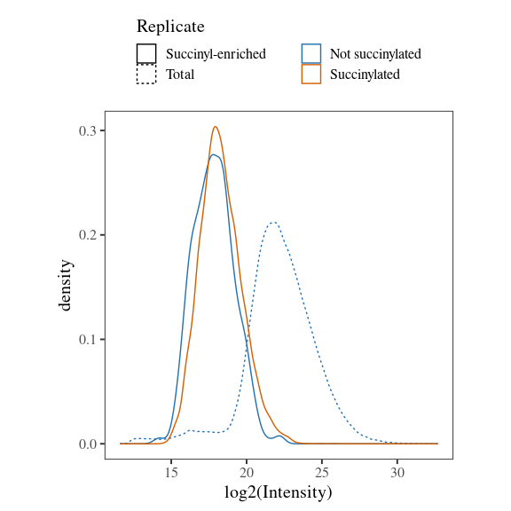

```r
intensities %>%
  ggplot(aes(log2(Intensity), colour=succ, linetype=type)) +
  geom_density() +
  theme_bw() +
  scale_colour_manual(name='', values=get_cat_palette(2)) +
  theme_camprot(base_size=15) +
  theme(legend.position='top', legend.direction='vertical') +
  scale_linetype_manual(name='Replicate', values=c('solid', 'dotted', 'dashed'))
```

Ok, so much higher intensity for unmodified LOPIT, as expected. Approximately 2^4 = 16-fold higher.

Parse the PTM scores, add filtered_* columns to detail filtering.

```r
raw_psm$succ <- parse_PTM_scores(raw_psm$succ, ptm_col="ptmRS.Best.Site.Probabilities", threshold=75)
```

```
Removed 0 Features where the ptm_col value == `Inconclusive data`
Total Features: 9567
Total detected PTMFeatures: 8755
Features passing filter: 8730
Features failing filter: 25
BiPTM/multiPTM Features where some sites fail filter: 2
Total detected sites: 8808
Sites passing filter: 8755
Sites failing filter: 53
monoPTM passing filter: 8706
biPTM passing filter: 23
multiPTM passing filter: 1
Too many isoforms: 0
```

```r
raw_psm$succ <- raw_psm$succ %>% filter(filtered_score!="") # The filtering doesn't actually take place until this step
raw_psm %>% lapply(dim)
```

```
$unmod
[1] 105184     62

$succ
[1] 8730   74
```

Add the position of the succinylation

```r
raw_psm$succ <- raw_psm$succ %>% add_PTM_positions(protein_fasta_inf)
```

Add the positions of the peptides

```r
raw_psm$succ <- raw_psm$succ %>% add_peptide_positions(protein_fasta_inf)

raw_psm %>% lapply(dim)
```

```
$unmod
[1] 105184     62

$succ
[1] 8730   77
```

Convert to MSnSets

```r
sample_infile = "../raw/samples.tsv"
sample_info <- read.delim(sample_infile) %>% tibble::column_to_rownames('Tag')

makeMsnset <- function(obj, sinfo){

  abundance_cols <- colnames(obj)[grepl('Abundance.', colnames(obj))]
  psm_e <- as.matrix(obj[,abundance_cols])
  psm_f <- obj[,setdiff(colnames(obj), abundance_cols)]

  # update the column names to remove the 'Abundance.` prefix
  colnames(psm_e) <- gsub('Abundance.', '', colnames(psm_e))
  psm_e <- psm_e[,rownames(sinfo)]

  res <- MSnbase::MSnSet(exprs=psm_e, fData=psm_f, pData=sinfo)

  res <- res[,pData(res)$Sample_name!='Total cell lysate']

  return(res)
}

psm_res <- raw_psm %>% lapply(function(x) makeMsnset(x, sample_info))
psm_res %>% lapply(dim)
```

```
$unmod
[1] 105184     10

$succ
[1] 8730   10
```

Remove features without quantification values

```r
psm_res <- psm_res %>% lapply(function(x){
  x <- x[rowSums(!is.na(exprs(x)))>0, ]
  camprotR:::message_parse(fData(x), 'Master.Protein.Accessions', "features without quantification removed")
  x
})
```

```
104199 features found from 8061 master proteins => features without quantification removed
8684 features found from 1977 master proteins => features without quantification removed
```

```r
psm_res %>% lapply(dim)
```

```
$unmod
[1] 104199     10

$succ
[1] 8684   10
```

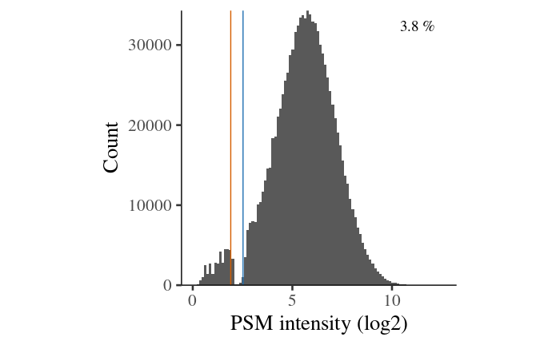

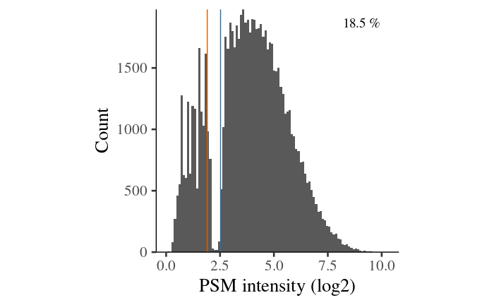

```r
psm_res %>% lapply(plot_TMT_notch)
```

OK, so as expected, with lots of lower intensity PSMs, the notch is more prominent in the succinylation sample, so there will be some underestimation of very low intensities in the succinyl LOPIT (see https://pubs.acs.org/doi/10.1021/acs.jproteome.7b00092 & https://www.biorxiv.org/content/10.1101/2021.07.18.452841v1.full (in print))

Excluding PSMs with SN<5 or interference > 50%

```r
psm_res <- psm_res %>% lapply(function(x) camprotR::filter_TMT_PSMs(x, inter_thresh=50, sn_thresh=5))
```

```
Filtering PSMs...
104199 features found from 8061 master proteins => No quant filtering
98051 features found from 7955 master proteins => Co-isolation filtering
95787 features found from 7937 master proteins => S:N ratio filtering
Filtering PSMs...
8684 features found from 1977 master proteins => No quant filtering
7945 features found from 1880 master proteins => Co-isolation filtering
6667 features found from 1630 master proteins => S:N ratio filtering
```

```r
psm_res %>% lapply(dim)
```

```
$unmod
[1] 95787    10

$succ
[1] 6667   10
```

Note, this also makes the notch less prominent

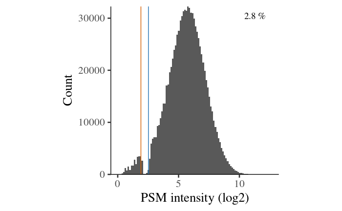

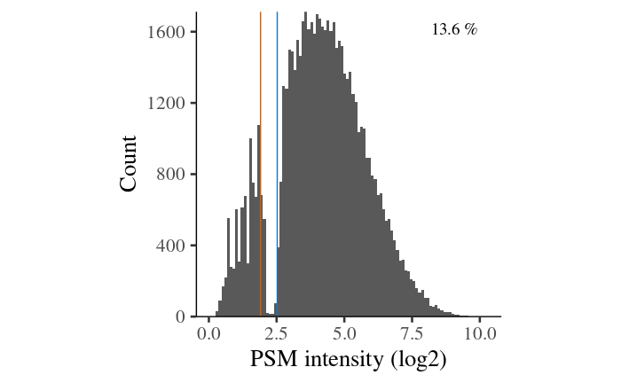

```r
psm_res %>% lapply(plot_TMT_notch)
```

Plot missing values

```
    0     1     2     3     4     5     6
92026  2243   793   446   214    57     8
```

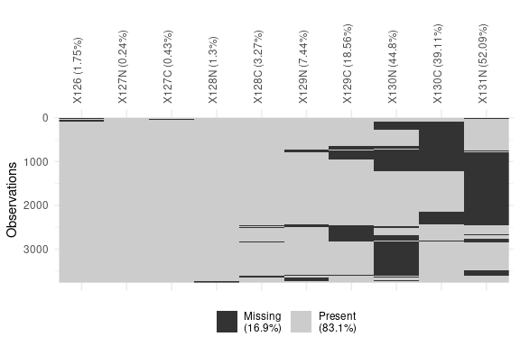

[output not shown]

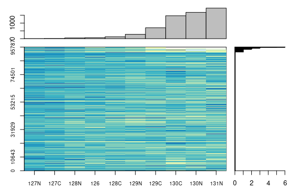

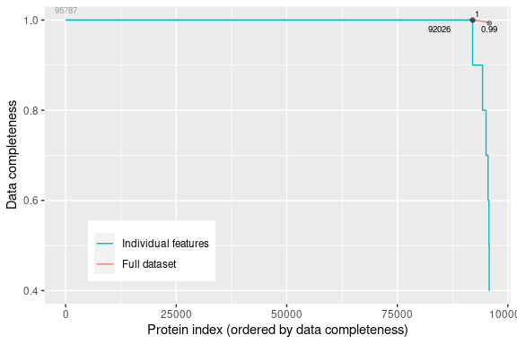

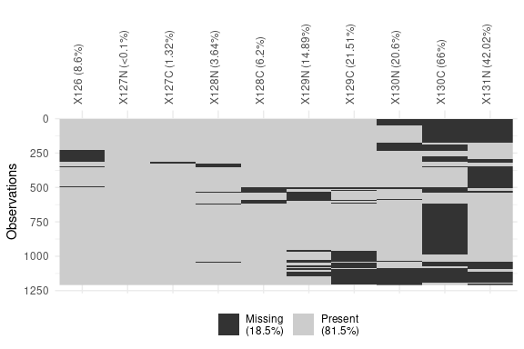

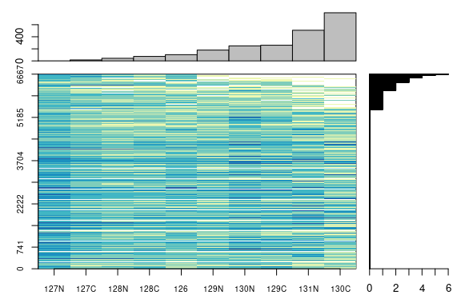

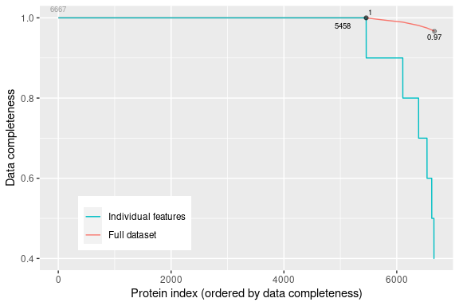

```r
library(RColorBrewer)
psm_res %>% lapply(function(x){

  print(table(rowSums(is.na(exprs(x)))))

  p <- x[rowSums(is.na(exprs(x)))>0,] %>% exprs() %>% data.frame() %>% naniar::vis_miss(cluster=TRUE) + theme(axis.text.x=element_text(angle=90))
  print(p)

  x %>% log(base=2) %>% naplot(col=brewer.pal(n = 8, name = "YlGnBu")[2:8])

  x %>% plotNA(pNA=0) + xlab('PSM index (ordered by data completeness)') + theme_camprot()

  return(NULL)
})
```

OK, so the majority of PSMs have no missing values, even for succinyl LOPIT, but where there are missing values, these are generally in the last fractions. We expect this is just due to values falling below the threshold of detection. In which case, should see relationship to average signal:noise for the PSM as a whole

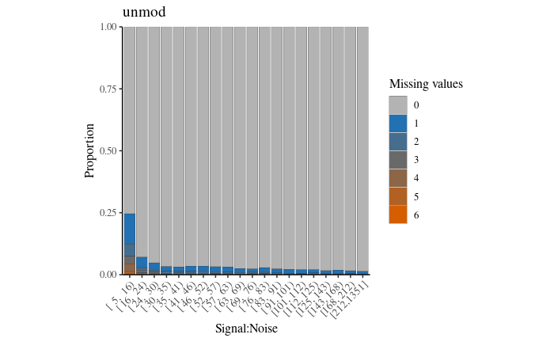

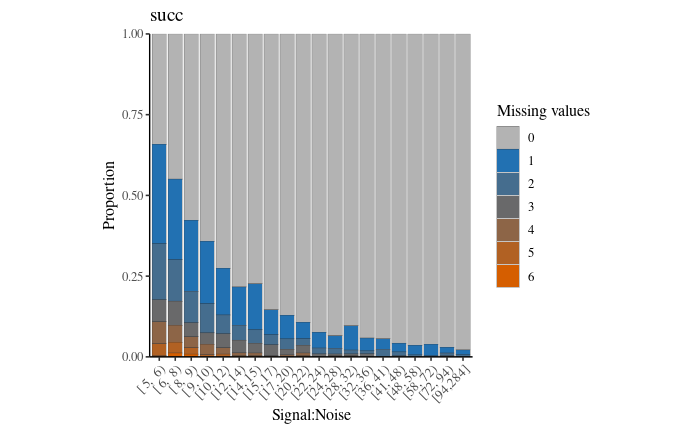

```r
psm_res %>% names() %>% lapply(function(x){
  p <- camprotR::plot_missing_SN(psm_res[[x]]) +
    ggtitle(x)
})
```

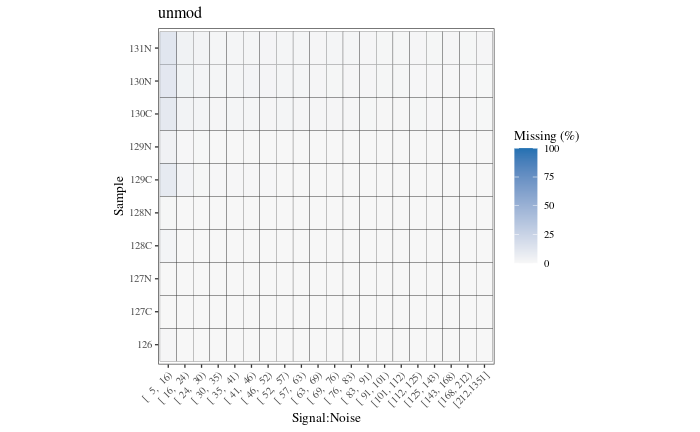

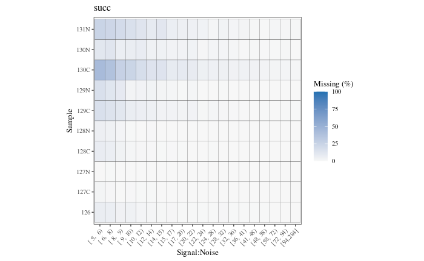

```r
psm_res %>% names() %>% lapply(function(x){
  p <- camprotR::plot_missing_SN_per_sample(psm_res[[x]]) +
    ggtitle(x)
})
```

Yes, looks like missing is due to low intensity.

Below we impute up to three missing values per PSM, using KNN (k=10) after performing sum normalisation on the rows first (to make sure the nearest neighbours have the same profile over the tags, rather than just the same overall intensity). Sum normalisation is reversed after imputation.

```r
library(OptProc)

ImputeMissing <- function(obj, missing=3, method="sn-knn", k=10){
  exprs(obj)[exprs(obj)==0]<- NA
  cat(sprintf("Discarding %s entries with more than %s missing values",
              sum(rowSums(is.na(exprs(obj)))>missing), missing))
  print(dim(obj))
  obj <- obj[rowSums(is.na(exprs(obj)))<=missing,]
  print(dim(obj))

  proteins_with_imputation <- rownames(obj[rowSums(is.na(exprs(obj)))>0,])
  print(length(proteins_with_imputation))

  if(method=="na"){
    obj_impute <- obj
  }
  else{
    sink("/dev/null")
    obj_impute <- OptProc::imputeOptProc(obj, method=method, k=k)
    sink()
  }

  fData(obj_impute)$imputed <- ifelse(rownames(obj_impute) %in% proteins_with_imputation, "Imputed", "Not imputed")
  print(table(fData(obj_impute)$imputed))

  invisible(obj_impute)
}
```

```r
psm_res_imp <- psm_res %>% lapply(ImputeMissing)
```

```
Discarding 279 entries with more than 3 missing values[1] 95787    10
[1] 95508    10
[1] 3482

    Imputed Not imputed
       3482       92026
Discarding 131 entries with more than 3 missing values[1] 6667   10
[1] 6536   10
[1] 1078

    Imputed Not imputed
       1078        5458
```

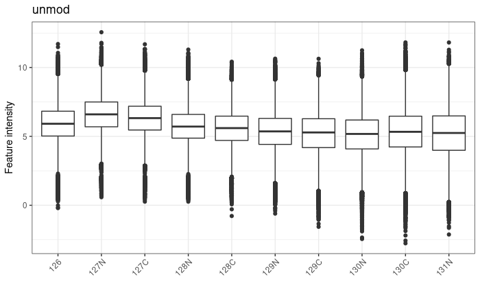

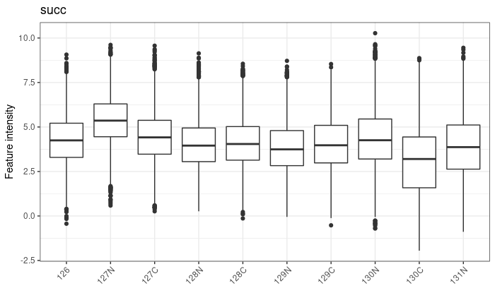

```r
psm_res_imp %>% names() %>% lapply(function(x){
  p <- camprotR::plot_quant(log(psm_res_imp[[x]], base=2)) +
    ggtitle(x)
})
```

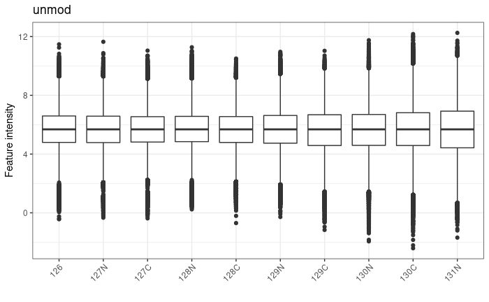

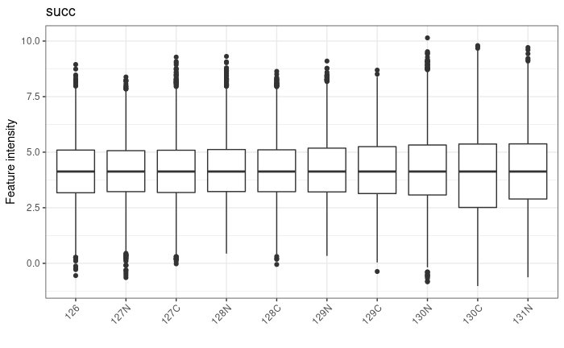

```r
psm_res_imp_cm %>% names() %>% lapply(function(x){
  p <- camprotR::plot_quant(log(psm_res_imp_cm[[x]], base=2)) +
    ggtitle(x)
})
```

[output not shown]

Combine PSMs to PTM phopeptides. Note that we are summarising PTM peptides using combination of Sequence and PTM position(s)

```r
ptm_pep_group <- paste(fData(psm_res_imp_cm$succ)$Sequence, fData(psm_res_imp_cm$succ)$ptm_position, sep=': ')
print(length(ptm_pep_group))
```

```
[1] 6536
```

```r
print(length(unique(ptm_pep_group)))
```

```
[1] 5979
```

```r
succ_pep <- MSnbase::combineFeatures(psm_res_imp_cm$succ, groupBy=ptm_pep_group, method='sum')
succ_pep
```

```
MSnSet (storageMode: lockedEnvironment)
assayData: 5979 features, 10 samples
  element names: exprs
protocolData: none
phenoData
  sampleNames: 126 127N ... 131N (10 total)
  varLabels: Sample_name
  varMetadata: labelDescription
featureData
  featureNames: AAAAAAALQAK: 364 AAAFEQLQK: 168 ... YYVTIIDAPGHRDFIK: 100 (5979 total)
  fvarLabels: Checked Confidence ... CV.131N (77 total)
  fvarMetadata: labelDescription
experimentData: use 'experimentData(object)'
Annotation:
- - - Processing information - - -
Subset [8730,11][8730,10] Mon Nov  8 23:43:49 2021
Subset [8730,10][8684,10] Mon Nov  8 23:43:49 2021
Subset [8684,10][8684,10] Mon Nov  8 23:44:07 2021
Subset [8684,10][7945,10] Mon Nov  8 23:44:07 2021
Subset [7945,10][6667,10] Mon Nov  8 23:44:07 2021
Subset [6667,10][6536,10] Mon Nov  8 23:59:19 2021
Normalised (sum): Mon Nov  8 23:59:19 2021
Data imputation using knn Mon Nov  8 23:59:19 2021
  Using parameter(s) k=10
Log transformed (base 2) Tue Nov  9 00:06:28 2021
Normalised (diff.median): Tue Nov  9 00:06:28 2021
Combined 6536 features into 5979 using sum: Tue Nov  9 00:06:54 2021
 MSnbase version: 2.14.2
```

```r
pep_group <- fData(psm_res_imp_cm$unmod)$Sequence
print(length(pep_group))
```

```
[1] 95508
```

```r
print(length(unique(pep_group)))
```

```
[1] 73793
```

```r
unmod_pep <- MSnbase::combineFeatures(psm_res_imp_cm$unmod, groupBy=pep_group, method='sum')

prot_group <- fData(psm_res_imp_cm$unmod)$Master.Protein.Accessions
print(length(prot_group))
```

```
[1] 95508
```

```r
print(length(unique(prot_group)))
```

```
[1] 7933
```

```r
unmod_prot <- MSnbase::combineFeatures(psm_res_imp_cm$unmod, groupBy=prot_group, method='sum')
```

Before we save out the MsnSets, we need to add the markers.

```r
markers_df <- read.delim("../shared_files/markers_9B_hyperLOPIT_vs_DC.csv", sep=",", header=FALSE, stringsAsFactors=FALSE)[,1:2]

markers_df$V2 <- Hmisc::capitalize(tolower(markers_df$V2))
markers_df$V2 <- recode(markers_df$V2,
                        "Ribosome 40s"="Ribosome",
                        "Ribosome 60s"="Ribosome",
                        "Nucleus-chromatin"="Nucleus",
                        "Er"="ER",
                        "Pm"="PM")

markers_proteins <- markers_df$V2
names(markers_proteins) <- markers_df$V1


unmod_prot <- pRoloc::addMarkers(unmod_prot, markers_proteins)
```

```
Markers in data: 779 out of 7933
```

```
organelleMarkers
     Cytosol           ER        Golgi     Lysosome Mitochondria      Nucleus   Peroxisome           PM   Proteasome     Ribosome      unknown
          81           97           56           39          177          134           20           77           31           67         7154
```

Below, we add the peptide-level markers. Note that we need to map from the Uniprot accession for the marker proteins to our unique identifier in order to add markers to the MsnSet object.

```r
pep_to_prot <- unmod_pep %>%
  fData() %>%
  tibble::rownames_to_column("Sequence_ID") %>%
  dplyr::select("Sequence_ID","Master.Protein.Accessions") %>%
  unique()

markers_peptide_df <- pep_to_prot %>%
  merge(markers_df, by.x="Master.Protein.Accessions", by.y="V1") # merge markers with unique identifiers

markers_peptides <- markers_peptide_df$V2
names(markers_peptides) <- markers_peptide_df$Sequence_ID


unmod_pep <- pRoloc::addMarkers(unmod_pep, markers_peptides)
```

```
Markers in data: 10796 out of 73793
```

```
organelleMarkers
     Cytosol           ER        Golgi     Lysosome Mitochondria      Nucleus   Peroxisome           PM   Proteasome     Ribosome      unknown
        1085         1670          469          297         2465         2344          262          578          575         1051        62997
```

```r
succ_pep_to_prot <- succ_pep %>%
  fData() %>%
  tibble::rownames_to_column("Sequence_ID") %>%
  dplyr::select("Sequence_ID","Master.Protein.Accessions") %>%
  unique()

succ_markers_peptide_df <- succ_pep_to_prot %>%
  merge(markers_df, by.x="Master.Protein.Accessions", by.y="V1") # merge markers with unique identifiers

succ_markers_peptides <- succ_markers_peptide_df$V2
names(succ_markers_peptides) <- succ_markers_peptide_df$Sequence_ID


succ_pep <- pRoloc::addMarkers(succ_pep, succ_markers_peptides)
```

```
Markers in data: 1500 out of 5979
```

```
organelleMarkers
     Cytosol           ER        Golgi     Lysosome Mitochondria      Nucleus   Peroxisome           PM   Proteasome     Ribosome      unknown
         132          330           10           17          277          161           21           34           72          446         4479
```

Finally, we row sum normalise

```r
unmod_prot <- normalise(unmod_prot, method='sum')
unmod_pep <- normalise(unmod_pep, method='sum')
succ_pep <- normalise(succ_pep, method='sum')
```

Now, we save out the final MsnSet object for use in later notebooks.

```r
saveRDS(unmod_prot, "../results/unmod_prot.rds")
saveRDS(unmod_pep, "../results/unmod_pep.rds")
saveRDS(succ_pep, "../results/succ_pep.rds")
```